# Exploring the role L1 retrotransposon expression plays in the outcomes of Cancer Patients

## Evan Dartez

https://esdartez.github.io/

## Background Information

L1s are a type of mobile repetitive element in the human genome. They are able to replicate and reinsert themselves in a different genetic locus causing mutations. This can have benign effects, or it can cause diseases such as Alzheimer’s, Huntington’s and various forms of cancer. L1’s make up roughly 17% of the human genome, but most L1s are inactive. However, the younger, active families of L1 are still potentially mobile and can cause these diseases.

## Data Source Information

The data was obtained with permission from The Cancer Genome Atlas Program from GDC. A copy of the RUS can be found below. The TCGA collects thousands of cancer patient's sequencing data and compiles them into cohorts based on cancer types. My lab works primarily with modeling high grade serous ovarian cancer (HGSOC) and L1's role in cancer development. We pulled data from the TCGA-OV cohort which contains all the ovarian cancer data. To select my population from this cohort, I found a paper from a similar study, “A genome-wide strategy to identify causes and consequences of retrotransposon expression finds activation by BRCA1 in ovarian cancer” (Alkailani et al 2021). This paper observes a wide variety of transposable elements and does not focus on L1s or its subfamilies. The population in this paper was selected for the peer reviewed confirmation of validity and because transposable elements, which L1 is a type of, were confirmed to be expressed in these samples.

### Data RUS:

The overall goal of this project is to develop and validate predictive models of patient outcomes using L1 retrotransposon expression as a primary predictor. L1 elements are mobile genetic sequences whose expression have been implicated in a variety of pathological processes including cancer progression. Using this dataset, we aim to explore the relationship between L1 expression levels and clinical outcomes across the patient populations. Specifically, we will quantify L1 expression levels across different clinical conditions, develop predictive models linking L1 expression to patient outcome, and identify any potential covariates that may affect these associations.

## Data Acquisition and Preprocessing

First, download the .bam files (sequencing data) from TCGA-OV for the population of patients listed. Run an element quantification program on the sequencing data. Popular quantification programs include TEtranscripts by Hammell Labratory and L1EM by FenyoLab. Both of these programs use expectation maximization to get local counts of genetic elements based on a gene index and an element index and output raw unnormalized counts (L1EM does not use a gene index and you must source gene counts from a different program such as TEtranscripts if you want to use size factor normalization).

```python
'''
You can install and then run TEtranscripts on your terminal with the command:
TEcount -b RNAseq BAM \
               --GTF genic-GTF-file \
               --TE TE-GTF-file \
               [optional arguments]

After installing L1EM, it can be run with the following:
bash -e /fullpathto/run_L1EM.sh /fullpathto/alignments.bam /fullpathto/L1EM /fullpathto/hg38.fa
'''
```

```
'\nYou can install and then run TEtranscripts on your terminal with the command:\nTEcount -b RNAseq BAM \\ \n               --GTF genic-GTF-file \\ \n               --TE TE-GTF-file \\ \n               [optional arguments]\n\nAfter installing L1EM, it can be run with the following:\nbash -e /fullpat…
```

## Extraction, Transform, Load

```python
#Import libraries needed for the DE
import pandas as pd
import statsmodels.api as sm
from scipy import stats
import numpy as np
```

```python
data = pd.read_excel('/content/counts.xlsx')
```

```python
#Observe the Initial Data
data.head(10)
```

|  | HGNC | Ensembl | C Alu | C L1PA | C L1PB | C ERV | T Alu | T L1PA | T L1PB | T ERV |
| --- | --- | --- | --- | --- | --- | --- | --- | --- | --- | --- |
| 0 | NaN | L1PA | 0.873075 | 1.000000 | 0.983254 | 0.897589 | 0.851998 | 1.000000 | 0.939614 | 0.783334 |
| 1 | NaN | L1PB | 0.833099 | 0.983254 | 1.000000 | 0.867418 | 0.880210 | 0.939614 | 1.000000 | 0.819702 |
| 2 | NaN | Alu | 1.000000 | 0.873075 | 0.833099 | 0.971796 | 1.000000 | 0.851998 | 0.880210 | 0.780238 |
| 3 | NaN | ERV | 0.971796 | 0.897589 | 0.867418 | 1.000000 | 0.780238 | 0.783334 | 0.819702 | 1.000000 |
| 4 | RBM25 | ENSG00000119707 | 0.301697 | 0.352927 | 0.342204 | 0.269581 | 0.606688 | 0.637690 | 0.647735 | 0.482653 |
| 5 | NKTR | ENSG00000114857 | 0.645472 | 0.711175 | 0.692158 | 0.625049 | 0.514399 | 0.628931 | 0.659856 | 0.556320 |
| 6 | AGAP6 | ENSG00000204149 | 0.351334 | 0.272516 | 0.243408 | 0.250595 | 0.557093 | 0.605480 | 0.608226 | 0.498523 |
| 7 | MT-CO1 | ENSG00000198804 | -0.015488 | 0.070048 | -0.041009 | -0.016697 | 0.459697 | 0.603934 | 0.415285 | 0.258546 |
| 8 | EBLN2 | ENSG00000255423 | 0.809798 | 0.818031 | 0.788998 | 0.817711 | 0.584162 | 0.589420 | 0.620453 | 0.450117 |
| 9 | SREK1 | ENSG00000153914 | 0.289608 | 0.351171 | 0.334064 | 0.268798 | 0.531867 | 0.574385 | 0.609202 | 0.451167 |

```python
# Create a results list to store computed metrics for each gene
results = []

# Loop over each gene to calculate differential expression metrics
for index, row in data.iterrows():
    gene = row['HGNC']

    # Extract expression data for health and ovarian cancer samples
    C_expr = [row['C Alu'], row['C L1PA'], row['C L1PB'], row['C ERV']]
    T_expr = [row['T Alu'], row['T L1PA'], row['T L1PB'], row['T ERV']]

    # Calculate the base mean (average expression across both groups)
    base_mean = np.mean(C_expr + T_expr)

    # Calculate log2 fold change: mean difference between healthy and ovarian groups
    mean_brca = np.mean(C_expr)
    mean_ov = np.mean(T_expr)
    log2_fc = np.log2(mean_brca + 1) - np.log2(mean_ov + 1)  # add 1 to avoid log(0) which is undefined

    # Standard error of log2 fold change
    lfc_se = np.std([np.log2(x + 1) for x in C_expr] + [np.log2(y + 1) for y in T_expr]) / np.sqrt(len(C_expr) + len(T_expr))

    # Perform t-test to obtain p-value and statistic
    t_stat, p_value = stats.ttest_ind(C_expr, T_expr, equal_var=False)  # Welch's t-test for unequal variances

    # Append the results for this gene
    results.append({
        'Gene': gene,
        'baseMean': base_mean,
        'log2FoldChange': log2_fc,
        'lfcSE': lfc_se,
        'stat': t_stat,
        'pvalue': p_value
    })

# Convert the results list to a DataFrame
results_df = pd.DataFrame(results)

# Adjust p-values for multiple testing using Benjamini-Hochberg (FDR)
results_df = results_df.sort_values(by='pvalue').reset_index(drop=True)
n = len(results_df)
results_df['padj'] = results_df['pvalue'] * n / (results_df.index + 1)
results_df['padj'] = results_df['padj'].clip(upper=1)  # Ensure adjusted p-values do not exceed 1

# Display the results DataFrame
results_df.head()
```

|  | Gene | baseMean | log2FoldChange | lfcSE | stat | pvalue | padj |
| --- | --- | --- | --- | --- | --- | --- | --- |
| 0 | OR2A14 | 0.354985 | 0.504623 | 0.089264 | 74.452153 | 4.888037e-10 | 0.000010 |
| 1 | RBMXL3 | 0.339876 | 0.512181 | 0.090597 | 78.222513 | 5.388866e-10 | 0.000005 |
| 2 | NaN | 0.046458 | 0.129677 | 0.022935 | 78.367329 | 7.404153e-10 | 0.000005 |
| 3 | OR2A5 | 0.348587 | 0.600358 | 0.106214 | 69.256555 | 7.961931e-10 | 0.000004 |
| 4 | CAV3 | 0.440289 | 0.694587 | 0.122906 | 62.048768 | 1.190651e-09 | 0.000005 |

## Exploratory Data Analysis

```python
import matplotlib.pyplot as plt
import seaborn as sns
```

```python
# Basic summary of the data
print(results_df.describe())
```

```
           baseMean  log2FoldChange         lfcSE          stat        pvalue  \
count  19724.000000    19724.000000  19724.000000  19724.000000  1.972400e+04
mean       0.031470       -0.002367      0.031408      0.101878  1.288423e-01
std        0.136199        0.202494      0.022261      8.103070  2.337588e-01
min       -0.300031       -1.158580      0.000000    -61.266864  4.888037e-10
25%       -0.052935       -0.126727      0.015797     -4.647473  1.267412e-03
50%        0.007243       -0.016570      0.025258     -0.744796  1.180354e-02
75%        0.091773        0.095502      0.040529      3.749358  1.276556e-01
max        0.916108        0.961811      0.206307     78.590310  9.993213e-01

               padj
count  19724.000000
mean       0.148347
std        0.244959
min        0.000004
25%        0.005069
50%        0.023606
75%        0.170204
max        0.999367
```

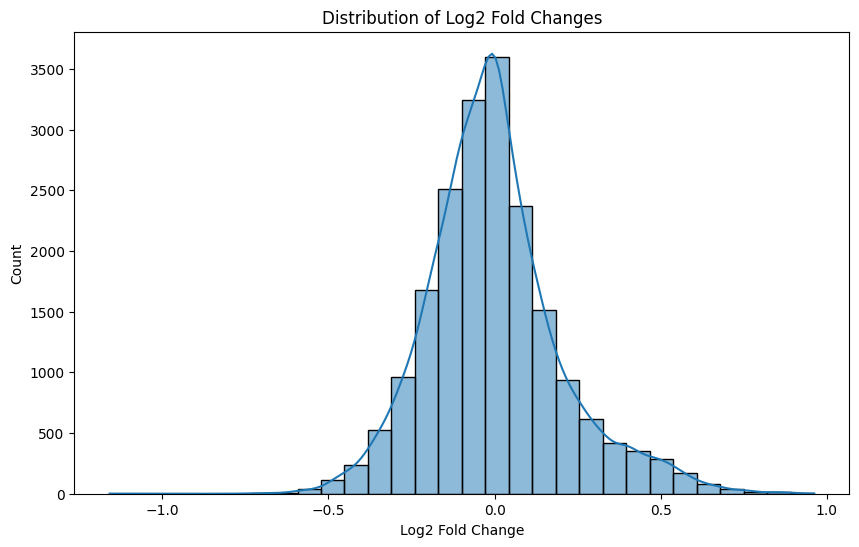

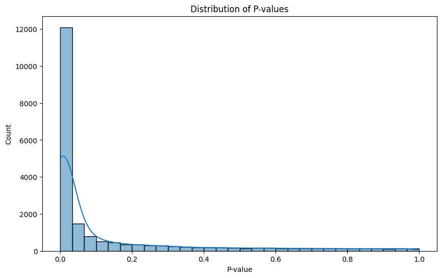

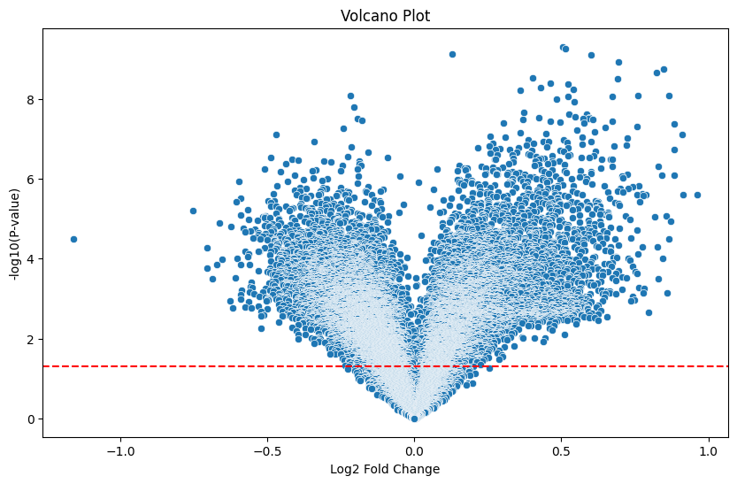

```
Number of significant genes (padj < 0.05): 11891
```

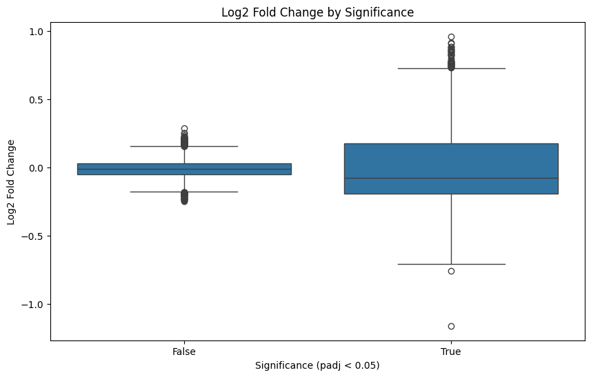

```python
# 1. Distribution of Log2 Fold Changes
plt.figure(figsize=(10, 6))
sns.histplot(results_df['log2FoldChange'], bins=30, kde=True)
plt.xlabel("Log2 Fold Change")
plt.title("Distribution of Log2 Fold Changes")
plt.show()

# 2. Distribution of P-values
plt.figure(figsize=(10, 6))
sns.histplot(results_df['pvalue'], bins=30, kde=True)
plt.xlabel("P-value")
plt.title("Distribution of P-values")
plt.show()

# 3. Volcano Plot (Log2 Fold Change vs -log10(P-value))
plt.figure(figsize=(10, 6))
sns.scatterplot(x='log2FoldChange', y=-np.log10(results_df['pvalue']), data=results_df)
plt.xlabel("Log2 Fold Change")
plt.ylabel("-log10(P-value)")
plt.title("Volcano Plot")
plt.axhline(y=-np.log10(0.05), color='red', linestyle='--')  # p-value threshold line
plt.show()

# 4. Significant Gene Count
# Define significance threshold (padj < 0.05)
significant_genes = results_df[results_df['padj'] < 0.05]
print(f"Number of significant genes (padj < 0.05): {len(significant_genes)}")

# 5. Boxplot of Log2 Fold Change for Significant vs Non-Significant Genes
results_df['significance'] = results_df['padj'] < 0.05
plt.figure(figsize=(10, 6))
sns.boxplot(x='significance', y='log2FoldChange', data=results_df)
plt.xlabel("Significance (padj < 0.05)")
plt.ylabel("Log2 Fold Change")
plt.title("Log2 Fold Change by Significance")
plt.show()
```

**Log2 Fold Change Distribution:** This histogram shows the distribution of log2 fold changes and shows the balance between upregulated and downregulated genes, providing and understanding of whether the data is skewed. The distribution here is balanced indicating that the gene expression is relatively even between up and down regulation.

**P-value Distribution:** This distribution can indicate the level of noise in the dataset and gauges the strength of the statistical test applied to each gene. The high concentration of values near 0 indicates that there is a clear signal in this data and that there is significant differences between the genes.

**Volcano Plot:** This plot combines the effect size indicated by log2 fold change and statistical significance indicated by p-value. This shows which genes are both statistically significant and biologically meaningful. The points that are further from the origin represent genes with a higher fold change and lower p-value. The red-line is the threshold which marks which genes pass the criteria and are candidates for further investigation.

**Boxplot:** This compares the distribution of log2fold changes between the significant and non-significant genes. The separatino inficates that the significant genes have higher fold changes and tells us that the observed differences are meaningful and not random.

## Retrieve and Load Patient Data (Additional ETL)

You can retrieve the patient data using the TCGA API and a list of TCGA patient ids.

```python
!pip install cbio-py
```

```python
#Create a dataset for the patient ids
patients = pd.read_excel('/content/patient_list.xlsx')
patient_ids = patients['patient']
```

```python
#Use the api to retrieve the patient info
from cbio_py import cbio_mod as cb

#We'll store the retrieved info here
patient_info = []

# Loop through each patient ID and retrieve clinical data across all studies
for patient_id in patient_ids:
    try:
        # Retrieve all studies that contain this patient ID
        studies = cb.getAllPatients(return_type='dict')
        # Filter studies for the specific patient ID
        for study in studies:
            if study['patientId'] == patient_id:
                study_id = study['studyId']
                # Retrieve clinical data for this patient in the specific study
                data = cb.getAllClinicalDataOfPatientInStudy(studyId=study_id, patientId=patient_id, return_type='dict')
                if data:
                    for record in data:
                        # Add patient ID and study ID to each record for context
                        record['patientId'] = patient_id
                        record['studyId'] = study_id
                        # Append the record to the patient_info list
                        patient_info.append(record)
    except Exception as e:
        print(f"Error retrieving data for patient {patient_id}: {e}")

# Convert the list of patient information to a DataFrame
patient_df = pd.DataFrame(patient_info)

# Display the DataFrame
print(patient_df.head())
```

[output not shown]

```python
clinical_outcomes = patient_df[['patientId', 'clinicalAttributeId', 'value']]
diff_expr_df = results_df
```

```python
#Tidy the clinical dataframe
#Remove duplicates
# Find duplicate entries based on patientId and clinicalAttributeId
duplicates = clinical_outcomes[clinical_outcomes.duplicated(subset=['patientId', 'clinicalAttributeId'], keep=False)]
print("Duplicate entries:")
print(duplicates)
```

```
Duplicate entries:
         patientId clinicalAttributeId                                 value
0     TCGA-04-1331          DFS_MONTHS                                 15.08
1     TCGA-04-1331          DFS_STATUS                 1:Recurred/Progressed
2     TCGA-04-1331           OS_MONTHS                                 43.89
3     TCGA-04-1331           OS_STATUS                            1:DECEASED
6     TCGA-04-1331        SAMPLE_COUNT                                     1
...            ...                 ...                                   ...
4158  TCGA-61-2095           OS_STATUS                            1:DECEASED
4159  TCGA-61-2095    OTHER_PATIENT_ID  778ce436-a825-4689-81c1-b7c965404163
4163  TCGA-61-2095                RACE                                 White
4166  TCGA-61-2095        SAMPLE_COUNT                                     1
4167  TCGA-61-2095                 SEX                                Female

[2266 rows x 3 columns]
```

```python
clinical_outcomes = clinical_outcomes.drop_duplicates(subset=['patientId', 'clinicalAttributeId'], keep='first')
```

```python
# Pivot the data to create one row per patient with relevant outcome and demographic columns
clinical_pivot = clinical_outcomes.pivot(index='patientId', columns='clinicalAttributeId', values='value').reset_index()

# Rename columns for readability, including the newly added attributes
clinical_pivot.columns.name = None
clinical_pivot.rename(columns={
    'DFS_STATUS': 'disease_free_status',
    'OS_STATUS': 'overall_survival_status',
    'DFS_MONTHS': 'disease_free_months',
    'OS_MONTHS': 'overall_survival_months',
    'RACE': 'race',
    'GENETIC_ANCESTRY_LABEL': 'genetic_ancestry_label',
    'ETHNICITY': 'ethnicity',
    'AGE': 'age'
}, inplace=True)

# Display the updated clinical_pivot DataFrame
print(clinical_pivot.head())
```

```
      patientId age BIOPSY_SITE BUFFA_HYPOXIA_SCORE CANCER_TYPE_ACRONYM  \
0  TCGA-04-1331  78       Ovary                 NaN                  OV
1  TCGA-04-1347  81       Ovary                 NaN                  OV
2  TCGA-04-1349  69       Ovary                 NaN                  OV
3  TCGA-04-1367  50       Ovary                 NaN                  OV
4  TCGA-04-1371  58       Ovary                 NaN                  OV

  CLINICAL_STAGE DAYS_LAST_FOLLOWUP DAYS_TO_BIRTH  \
0     Stage IIIC               1224        -28848
1       Stage IV               1919        -29695
2       Stage IV                NaN        -25213
3     Stage IIIC               3145        -18577
4     Stage IIIC               2506        -21243

  DAYS_TO_INITIAL_PATHOLOGIC_DIAGNOSIS disease_free_months  ... SAMPLE_COUNT  \
```

[output cut: 21 more lines]

```python
# Add a 'significant' column based on the 'padj' values.
diff_expr_df['significance'] = diff_expr_df['padj'] < 0.05
#First we extract the significant genes from our differential expression
significant_genes_df = diff_expr_df[diff_expr_df['significance'] == True]

# Display the significant genes
print(significant_genes_df[['Gene', 'log2FoldChange', 'pvalue']].head())
```

```
     Gene  log2FoldChange        pvalue
0  OR2A14        0.504623  4.888037e-10
1  RBMXL3        0.512181  5.388866e-10
2     NaN        0.129677  7.404153e-10
3   OR2A5        0.600358  7.961931e-10
4    CAV3        0.694587  1.190651e-09
```

```python
'''
We need to map the genes to the patient data. There are many different genes in our differential expression. We are going to use mygene, a library that retrieves gene annotations
so that we can effectively map the genes to the patient data.
'''
!pip install mygene
```

```python
import mygene

# Initialize the mygene query
mg = mygene.MyGeneInfo()

# List of genes to query (from the significant genes DataFrame)
genes = significant_genes_df['Gene'].tolist()

# Query mygene to get gene families or functions
annotations = mg.querymany(genes, scopes='symbol', fields='go.BP', species='human')  # Using biological process (BP) GO terms

# Convert annotations to DataFrame for review
annotations_df = pd.json_normalize(annotations)
```

[output not shown]

```python
annotations_df.head()
```

|  | query | _id | _score | go.BP | go.BP.evidence | go.BP.gocategory | go.BP.id | go.BP.qualifier | go.BP.term | notfound | go.BP.pubmed |
| --- | --- | --- | --- | --- | --- | --- | --- | --- | --- | --- | --- |
| 0 | OR2A14 | 135941 | 23.844420 | [{'evidence': 'IEA', 'gocategory': 'BP', 'id':... | NaN | NaN | NaN | NaN | NaN | NaN | NaN |
| 1 | RBMXL3 | 139804 | 22.933352 | NaN | IBA | BP | GO:0000398 | involved_in | mRNA splicing, via spliceosome | NaN | NaN |
| 2 | nan | NaN | NaN | NaN | NaN | NaN | NaN | NaN | NaN | True | NaN |
| 3 | OR2A5 | 393046 | 23.236755 | [{'evidence': 'IEA', 'gocategory': 'BP', 'id':... | NaN | NaN | NaN | NaN | NaN | NaN | NaN |
| 4 | CAV3 | 859 | 17.651184 | [{'evidence': 'IEA', 'gocategory': 'BP', 'id':... | NaN | NaN | NaN | NaN | NaN | NaN | NaN |

```python
# Simplify to show gene and its primary biological process for easy mapping
annotations_df = annotations_df[['query', 'go.BP']].dropna()
annotations_df.columns = ['Gene', 'Biological_Process']
print(annotations_df.head())
```

```
     Gene                                 Biological_Process
0  OR2A14  [{'evidence': 'IEA', 'gocategory': 'BP', 'id':...
3   OR2A5  [{'evidence': 'IEA', 'gocategory': 'BP', 'id':...
4    CAV3  [{'evidence': 'IEA', 'gocategory': 'BP', 'id':...
5  CYP3A7  [{'evidence': 'IDA', 'gocategory': 'BP', 'id':...
6  CLDN18  [{'evidence': 'IBA', 'gocategory': 'BP', 'id':...
```

```python
def categorize_gene_process(bp_terms):
    # This function takes a list of BP terms and assigns an outcome category based on common terms
    if any('immune response' in term['term'].lower() for term in bp_terms):
        return 'Aggressive Disease'
    elif any('cell proliferation' in term['term'].lower() for term in bp_terms):
        return 'Recurrence Risk'
    elif any('apoptosis' in term['term'].lower() for term in bp_terms):
        return 'Poor Survival'
    else:
        return 'General Risk'

# Apply categorization to each gene
annotations_df['Associated_Outcome'] = annotations_df['Biological_Process'].apply(categorize_gene_process)
print(annotations_df[['Gene', 'Associated_Outcome']].head())
```

```
     Gene Associated_Outcome
0  OR2A14       General Risk
3   OR2A5       General Risk
4    CAV3       General Risk
5  CYP3A7       General Risk
6  CLDN18    Recurrence Risk
```

```python
#Now we can annotate our differential expression
diff_expr_annotated_df = pd.merge(diff_expr_df, annotations_df, on='Gene', how='left')
#Drop any dans

diff_expr_annotated_df = diff_expr_annotated_df.dropna()
# Display the annotated differential expression data
print(diff_expr_annotated_df.head())
```

```
     Gene  baseMean  log2FoldChange     lfcSE       stat        pvalue  \
0  OR2A14  0.354985        0.504623  0.089264  74.452153  4.888037e-10
3   OR2A5  0.348587        0.600358  0.106214  69.256555  7.961931e-10
4    CAV3  0.440289        0.694587  0.122906  62.048768  1.190651e-09
5  CYP3A7  0.427027        0.848274  0.150140  61.940790  1.747570e-09
6  CLDN18  0.397380        0.824638  0.145937  58.620898  2.212082e-09

       padj  significance                                 Biological_Process  \
0  0.000010          True  [{'evidence': 'IEA', 'gocategory': 'BP', 'id':...
3  0.000004          True  [{'evidence': 'IEA', 'gocategory': 'BP', 'id':...
4  0.000005          True  [{'evidence': 'IEA', 'gocategory': 'BP', 'id':...
5  0.000006          True  [{'evidence': 'IDA', 'gocategory': 'BP', 'id':...
6  0.000006          True  [{'evidence': 'IBA', 'gocategory': 'BP', 'id':...

  Associated_Outcome
0       General Risk
3       General Risk
4       General Risk
5       General Risk
6    Recurrence Risk
```

```python
# Define a mapping for disease_free_status to align with Associated_Outcome
status_mapping = {
    '1:Recurred/Progressed': 'Recurrence Risk',
    '0:DiseaseFree': 'General Risk'
}

# Create a new column in clinical_pivot based on this mapping
clinical_pivot['Mapped_Outcome'] = clinical_pivot['disease_free_status'].map(status_mapping)

#Now we can merge the annotated differential expression with our patient data based on the annotations
merged_df = pd.merge(clinical_pivot, diff_expr_annotated_df, left_on='Mapped_Outcome', right_on='Associated_Outcome', how='inner')

# Display the final merged data
merged_df.head()
```

|  | patientId | age | BIOPSY_SITE | BUFFA_HYPOXIA_SCORE | CANCER_TYPE_ACRONYM | CLINICAL_STAGE | DAYS_LAST_FOLLOWUP | DAYS_TO_BIRTH | DAYS_TO_INITIAL_PATHOLOGIC_DIAGNOSIS | disease_free_months | ... | Gene | baseMean | log2FoldChange | lfcSE | stat | pvalue | padj | significance | Biological_Process | Associated_Outcome |
| --- | --- | --- | --- | --- | --- | --- | --- | --- | --- | --- | --- | --- | --- | --- | --- | --- | --- | --- | --- | --- | --- |
| 0 | TCGA-04-1331 | 78 | Ovary | NaN | OV | Stage IIIC | 1224 | -28848 | 0 | 15.08 | ... | CLDN18 | 0.397380 | 0.824638 | 0.145937 | 58.620898 | 2.212082e-09 | 0.000006 | True | [{'evidence': 'IBA', 'gocategory': 'BP', 'id':... | Recurrence Risk |
| 1 | TCGA-04-1331 | 78 | Ovary | NaN | OV | Stage IIIC | 1224 | -28848 | 0 | 15.08 | ... | WNT2B | 0.224196 | 0.353351 | 0.062711 | 29.433239 | 1.636515e-07 | 0.000046 | True | [{'evidence': 'IEP', 'gocategory': 'BP', 'id':... | Recurrence Risk |
| 2 | TCGA-04-1331 | 78 | Ovary | NaN | OV | Stage IIIC | 1224 | -28848 | 0 | 15.08 | ... | NRARP | -0.002367 | -0.157735 | 0.028007 | -26.106522 | 2.108839e-07 | 0.000051 | True | [{'evidence': 'IEA', 'gocategory': 'BP', 'id':... | Recurrence Risk |
| 3 | TCGA-04-1331 | 78 | Ovary | NaN | OV | Stage IIIC | 1224 | -28848 | 0 | 15.08 | ... | IHH | -0.030631 | 0.078575 | 0.013949 | 27.078664 | 5.795156e-07 | 0.000083 | True | [{'evidence': 'IMP', 'gocategory': 'BP', 'id':... | Recurrence Risk |
| 4 | TCGA-04-1331 | 78 | Ovary | NaN | OV | Stage IIIC | 1224 | -28848 | 0 | 15.08 | ... | HTR2B | 0.190614 | 0.600395 | 0.106820 | 26.053013 | 7.333905e-07 | 0.000090 | True | [{'evidence': 'ISS', 'gocategory': 'BP', 'id':... | Recurrence Risk |

5 rows × 75 columns

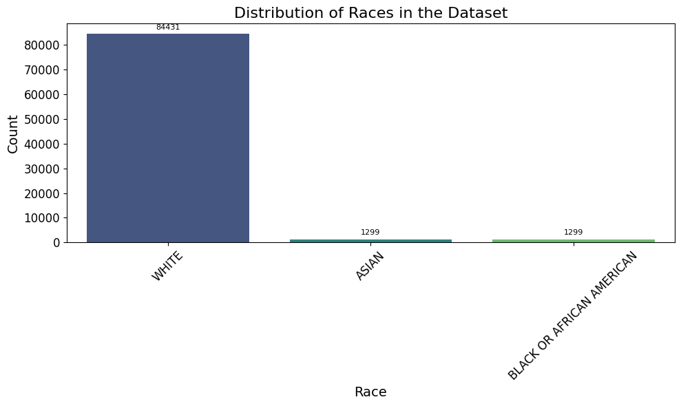

```python
plt.figure(figsize=(10, 6))
ax = sns.countplot(data=merged_df, x='race', order=merged_df['race'].value_counts().index, palette="viridis")

# Add counts above each bar
for p in ax.patches:
    ax.annotate(f'{int(p.get_height())}',
                (p.get_x() + p.get_width() / 2., p.get_height() - 0.5),  # Adjust to fit within the border
                ha='center', va='baseline', fontsize=8, color='black', xytext=(0, 5),
                textcoords='offset points')

plt.title("Distribution of Races in the Dataset", fontsize=16)
plt.xlabel("Race", fontsize=14)
plt.ylabel("Count", fontsize=14)
plt.xticks(rotation=45, fontsize=12)
plt.yticks(fontsize=12)
plt.tight_layout()
plt.show()
```

There population turned out to be not very diverse which can potentially cause bias based on genetic differences regarding race.

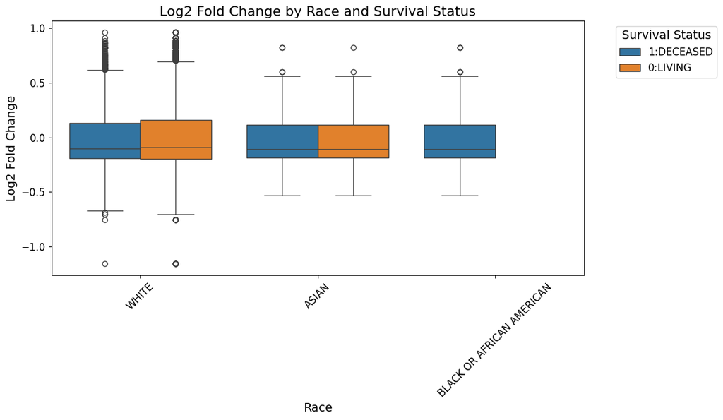

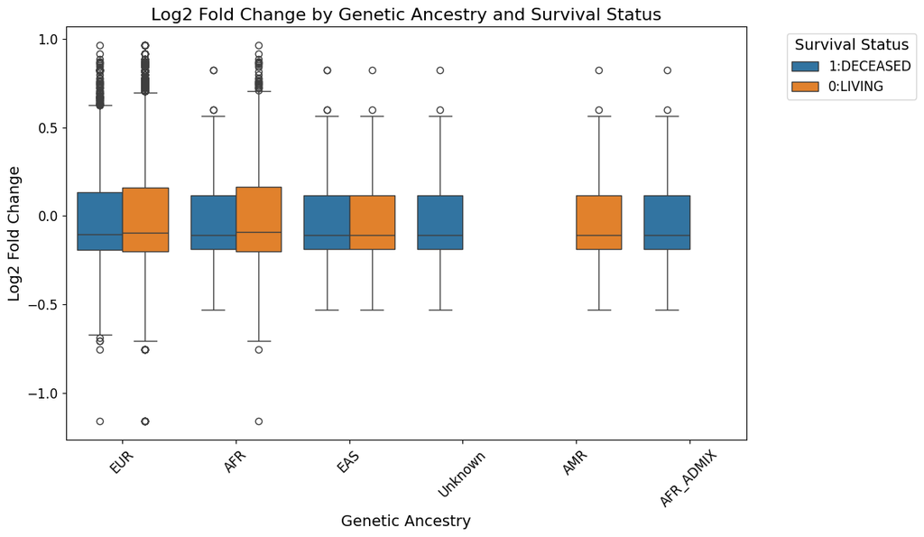

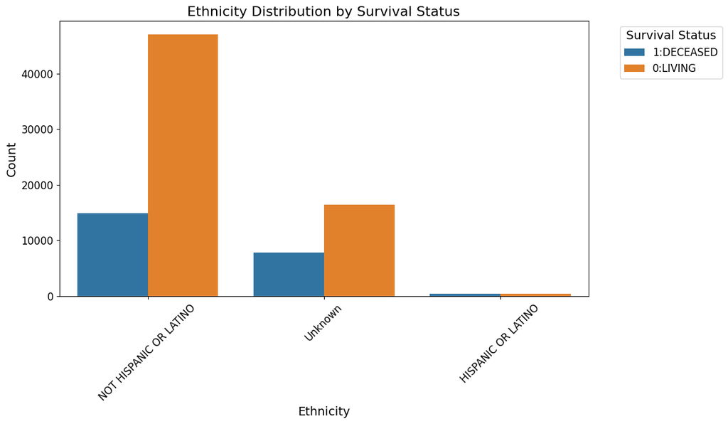

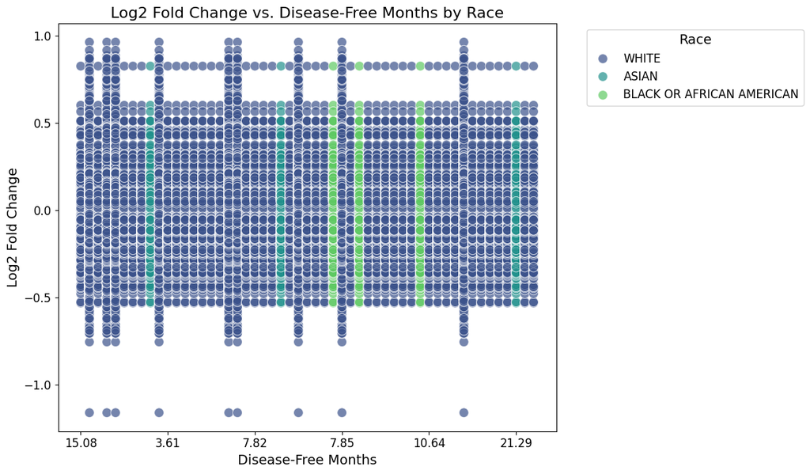

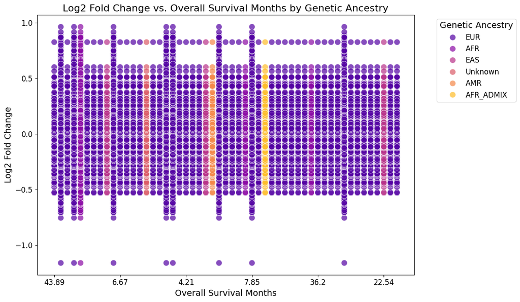

```python
# Boxplot: Log2 Fold Change by Race
plt.figure(figsize=(12, 7))
sns.boxplot(data=merged_df, x='race', y='log2FoldChange', hue='overall_survival_status', dodge=True)
plt.title("Log2 Fold Change by Race and Survival Status", fontsize=16)
plt.xticks(rotation=45, fontsize=12)
plt.yticks(fontsize=12)
plt.ylabel("Log2 Fold Change", fontsize=14)
plt.xlabel("Race", fontsize=14)
plt.legend(title="Survival Status", fontsize=12, title_fontsize=14, bbox_to_anchor=(1.05, 1), loc='upper left')
plt.tight_layout()
plt.show()

# Boxplot: Log2 Fold Change by Genetic Ancestry
plt.figure(figsize=(12, 7))
sns.boxplot(data=merged_df, x='genetic_ancestry_label', y='log2FoldChange', hue='overall_survival_status', dodge=True)
plt.title("Log2 Fold Change by Genetic Ancestry and Survival Status", fontsize=16)
plt.xticks(rotation=45, fontsize=12)
plt.yticks(fontsize=12)
plt.ylabel("Log2 Fold Change", fontsize=14)
plt.xlabel("Genetic Ancestry", fontsize=14)
plt.legend(title="Survival Status", fontsize=12, title_fontsize=14, bbox_to_anchor=(1.05, 1), loc='upper left')
plt.tight_layout()
plt.show()

# Countplot: Ethnicity Distribution by Outcome
plt.figure(figsize=(12, 7))
sns.countplot(data=merged_df, x='ethnicity', hue='overall_survival_status')
plt.title("Ethnicity Distribution by Survival Status", fontsize=16)
plt.xticks(rotation=45, fontsize=12)
plt.yticks(fontsize=12)
plt.xlabel("Ethnicity", fontsize=14)
plt.ylabel("Count", fontsize=14)
plt.legend(title="Survival Status", fontsize=12, title_fontsize=14, bbox_to_anchor=(1.05, 1), loc='upper left')
plt.tight_layout()
plt.show()

# Scatterplot: Log2 Fold Change vs Disease-Free Months by Race
plt.figure(figsize=(12, 7))
sns.scatterplot(data=merged_df, x='disease_free_months', y='log2FoldChange', hue='race', alpha=0.7, s=100, palette="viridis")
plt.title("Log2 Fold Change vs. Disease-Free Months by Race", fontsize=16)
plt.xticks(fontsize=12)
plt.yticks(fontsize=12)
plt.xlabel("Disease-Free Months", fontsize=14)
plt.ylabel("Log2 Fold Change", fontsize=14)
plt.legend(title="Race", fontsize=12, title_fontsize=14, bbox_to_anchor=(1.05, 1), loc='upper left')

# Show only every 10 months on x-axis
plt.xticks(ticks=plt.xticks()[0][::10], fontsize=12)
plt.tight_layout()
plt.show()

# Scatterplot: Log2 Fold Change vs Overall Survival Months by Genetic Ancestry
plt.figure(figsize=(12, 7))
sns.scatterplot(data=merged_df, x='overall_survival_months', y='log2FoldChange', hue='genetic_ancestry_label', alpha=0.7, s=100, palette="plasma")
plt.title("Log2 Fold Change vs. Overall Survival Months by Genetic Ancestry", fontsize=16)
plt.xticks(fontsize=12)
plt.yticks(fontsize=12)
plt.xlabel("Overall Survival Months", fontsize=14)
plt.ylabel("Log2 Fold Change", fontsize=14)
plt.legend(title="Genetic Ancestry", fontsize=12, title_fontsize=14, bbox_to_anchor=(1.05, 1), loc='upper left')

# Show only every 10 months on x-axis
plt.xticks(ticks=plt.xticks()[0][::10], fontsize=12)
plt.tight_layout()
plt.show()
```

**Log2 Fold Change by Race and Survival Status**

This plot shows the distribution of log2 fold changes across different racial groups (White, Asian, Black or African American) and survival statuses (Deceased vs. Living). There is no significant visible difference in the median log2 fold change between the deceased and living groups within each race. The spread of the distributions is slightly different, with some outliers present in all groups, but further statistical analysis would be needed to confirm any trends.

**Log2 Fold Change by Genetic Ancestry and Survival Status**

**Ethnicity Distribution by Survival Status**

This plot compares the counts of patients with different ethnicities (Not Hispanic or Latino, Hispanic or Latino, Unknown) for survival statuses. The majority of patients are Not Hispanic or Latino, with a higher count among the living compared to the deceased. The ethnicity labeled as Unknown also represents a significant portion of the data, which may affect interpretations. Very few patients are categorized as Hispanic or Latino, making it harder to draw conclusions for this group.

**Log2 Fold Change vs. Disease-Free Months by Race**

This scatterplot shows the relationship between log2 fold change and disease-free months, stratified by race. The data appears widely distributed, with no clear correlation between log2 fold change and disease-free months across racial groups. Clusters of data points are observed around specific intervals for disease-free months (such as approximately 15.08 and 7.85), which may reflect cohort-specific measurement intervals.

**Log2 Fold Change vs. Overall Survival Months by Genetic Ancestry**

This scatterplot examines the relationship between log2 fold change and overall survival months, categorized by genetic ancestry. Similar to the previous scatterplot, there is no strong apparent correlation between log2 fold change and overall survival months. Clusters of data points around specific intervals for overall survival months (such as approximately 43.89 and 7.85) suggest that survival measurements may have been recorded at discrete time points. Some ancestries, such as EUR and AFR, have more data points, reflecting larger sample sizes.

## Model

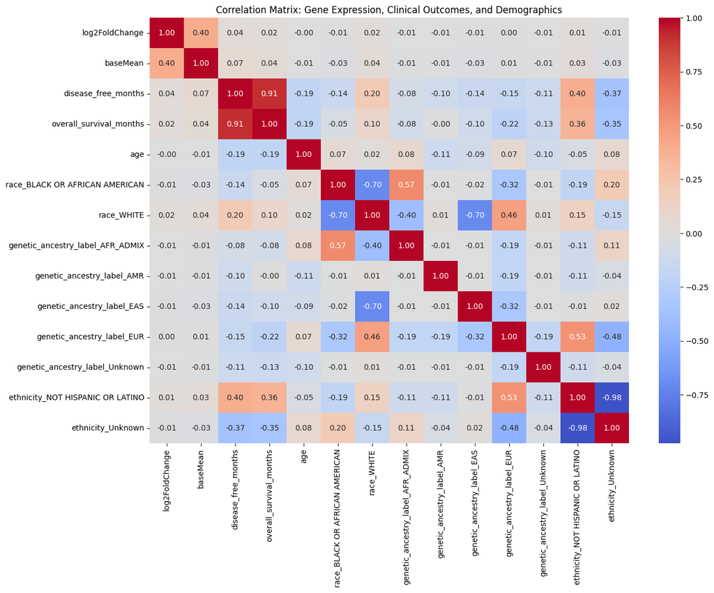

```python
from sklearn.preprocessing import OneHotEncoder
import pandas as pd
import seaborn as sns
import matplotlib.pyplot as plt

# Ensure categorical columns are strings and fill missing values
categorical_columns = ['race', 'genetic_ancestry_label', 'ethnicity']
merged_df[categorical_columns] = merged_df[categorical_columns].astype(str).fillna("Unknown")

# Initialize the OneHotEncoder
encoder = OneHotEncoder(drop='first', sparse_output=False)  # sparse_output=False returns a dense array directly

# Apply one-hot encoding to the categorical columns
encoded_data = encoder.fit_transform(merged_df[categorical_columns])

# Convert encoded data to a DataFrame
encoded_features = pd.DataFrame(
    encoded_data,
    columns=encoder.get_feature_names_out(categorical_columns),
    index=merged_df.index
)

# Combine encoded features with numerical columns for correlation analysis
correlation_df = pd.concat([
    merged_df[['log2FoldChange', 'baseMean', 'disease_free_months', 'overall_survival_months','age']],
    encoded_features
], axis=1).dropna()

# Calculate the correlation matrix
correlation_matrix = correlation_df.corr()

# Plot the correlation heatmap
plt.figure(figsize=(14, 10))
sns.heatmap(correlation_matrix, annot=True, fmt=".2f", cmap="coolwarm", center=0)
plt.title("Correlation Matrix: Gene Expression, Clinical Outcomes, and Demographics")
plt.show()
```

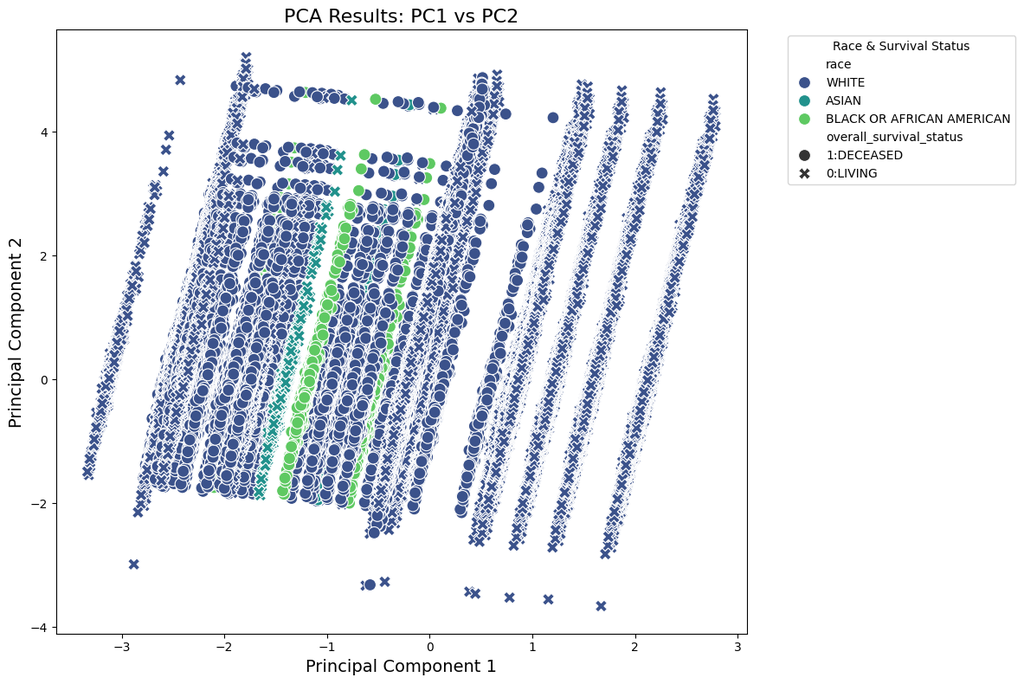

```
Explained Variance Ratio: PC1 = 0.40, PC2 = 0.28
```

```python
from sklearn.decomposition import PCA
from sklearn.preprocessing import StandardScaler
import pandas as pd
import matplotlib.pyplot as plt
import seaborn as sns

# Assuming `merged_df` is available and contains the necessary columns for PCA
# Select numerical columns for PCA (example: gene expression and clinical metrics)
numerical_columns = ['log2FoldChange', 'baseMean', 'disease_free_months', 'overall_survival_months','age']
pca_data = merged_df[numerical_columns].dropna()

# Standardize the data
scaler = StandardScaler()
scaled_data = scaler.fit_transform(pca_data)

# Apply PCA
pca = PCA(n_components=2)  # Reduce to 2 components for visualization
pca_result = pca.fit_transform(scaled_data)

# Create a DataFrame with PCA results
pca_df = pd.DataFrame(data=pca_result, columns=['PC1', 'PC2'])
pca_df['race'] = merged_df['race'].loc[pca_data.index]  # Add race for visualization
pca_df['overall_survival_status'] = merged_df['overall_survival_status'].loc[pca_data.index]  # Add survival status

# Plot PCA results
plt.figure(figsize=(12, 8))
sns.scatterplot(data=pca_df, x='PC1', y='PC2', hue='race', style='overall_survival_status', palette='viridis', s=100)
plt.title('PCA Results: PC1 vs PC2', fontsize=16)
plt.xlabel('Principal Component 1', fontsize=14)
plt.ylabel('Principal Component 2', fontsize=14)
plt.legend(title='Race & Survival Status', bbox_to_anchor=(1.05, 1), loc='upper left', fontsize=10)
plt.tight_layout()
plt.show()

# Explained variance ratio
explained_variance = pca.explained_variance_ratio_
print(f"Explained Variance Ratio: PC1 = {explained_variance[0]:.2f}, PC2 = {explained_variance[1]:.2f}")
```

```
Classification Report:
              precision    recall  f1-score   support

    0:LIVING       0.97      0.99      0.98     12778
  1:DECEASED       0.96      0.93      0.95      4628

    accuracy                           0.97     17406
   macro avg       0.97      0.96      0.96     17406
weighted avg       0.97      0.97      0.97     17406


Confusion Matrix:
[[12605   173]
 [  324  4304]]

Accuracy Score: 0.9714466275996783

Feature Importances:
                             Feature  Importance
2                                age    0.716933
1                           baseMean    0.068049
0                     log2FoldChange    0.066309
4                         race_WHITE    0.030063
8         genetic_ancestry_label_EUR    0.027791
11                 ethnicity_Unknown    0.027160
10  ethnicity_NOT HISPANIC OR LATINO    0.024066
3     race_BLACK OR AFRICAN AMERICAN    0.015491
9     genetic_ancestry_label_Unknown    0.010235
7         genetic_ancestry_label_EAS    0.008028
5   genetic_ancestry_label_AFR_ADMIX    0.003793
6         genetic_ancestry_label_AMR    0.002082
```

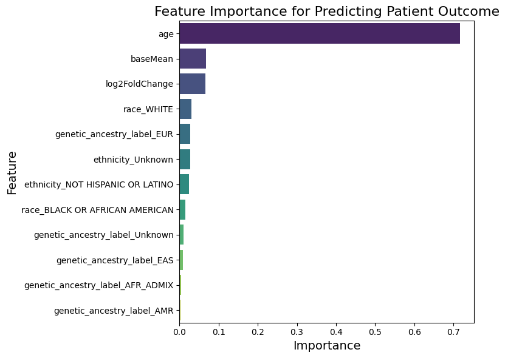

```python
from sklearn.model_selection import train_test_split
from sklearn.ensemble import RandomForestClassifier
from sklearn.metrics import classification_report, confusion_matrix, accuracy_score
# Create a DataFrame that includes numerical predictors plus the encoded features
# Here we include 'age', 'log2FoldChange', and 'baseMean' as numeric predictors
predictor_columns = ['log2FoldChange', 'baseMean', 'age']
X = pd.concat([
    merged_df[predictor_columns],
    encoded_features
], axis=1).dropna()

# The target variable
y = merged_df.loc[X.index, 'overall_survival_status']  # Align target with the same rows as X

# Split into training and test sets
# Use stratify=y if the target is binary and you want balanced splits
X_train, X_test, y_train, y_test = train_test_split(
    X, y, test_size=0.2, random_state=42, stratify=y
)

# Initialize and train the Random Forest Classifier
clf = RandomForestClassifier(random_state=42)
clf.fit(X_train, y_train)

# Make predictions
y_pred = clf.predict(X_test)

# Evaluate the model
print("Classification Report:")
print(classification_report(y_test, y_pred))

print("\nConfusion Matrix:")
print(confusion_matrix(y_test, y_pred))

print("\nAccuracy Score:", accuracy_score(y_test, y_pred))

# Compute feature importances
feature_importances = pd.DataFrame({
    'Feature': X.columns,
    'Importance': clf.feature_importances_
}).sort_values(by='Importance', ascending=False)

print("\nFeature Importances:")
print(feature_importances)

# Plot Feature Importance
plt.figure(figsize=(8, 6))
sns.barplot(data=feature_importances, x='Importance', y='Feature', palette='viridis')
plt.title("Feature Importance for Predicting Patient Outcome", fontsize=16)
plt.xlabel("Importance", fontsize=14)
plt.ylabel("Feature", fontsize=14)
plt.tight_layout()
plt.show()
```

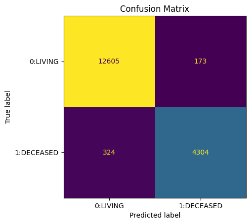

```python
from sklearn.metrics import ConfusionMatrixDisplay

# Plot confusion matrix as a heatmap
cm_display = ConfusionMatrixDisplay.from_estimator(clf, X_test, y_test, cmap='viridis', colorbar=False)
plt.title("Confusion Matrix")
plt.show()
```

I chose random forest for this analysis because it is a robust classifier that can handle numerical and categorical predictors effectively. It is good at handling imbalanced datasets, managing non-linear relationships, and provides feature importance scores. The model was trained on a dataset that combined key predictors (log2FoldChange, baseMean, age) with one-hot encoded demographic features ( race, genetic ancestry, and ethnicity). This integration ensures that both clinical and demographic factors are considered when predicting survival outcomes. Random Forest's inherent feature selection capability mitigates issues related to multicollinearity among predictors.

The model demonstrated high performance with a 97.1% accuracy.The confusion matrix showed minimal misclassifications, with a high recall for both living and deceased categories. However, this could be due to the imbalance in patient outcomes.

Feature importance analysis highlighted age as the most influential predictor, followed by gene expression metrics (baseMean and log2FoldChange). Demographic variables, while less impactful, still contributed meaningfully, reflecting their contextual relevance in survival predictions.

Some potential weaknesses in this model include:

-The model relies heavily on age, potentially overlooking the contributions of other features.

-High accuracy may indicate overfitting, reducing generalizability to unseen data.

-Random Forest's black-box nature makes individual predictions hard to explain to clinicians.

## Conclusions and Recommendations

The null hypothesis stated that L1 retrotransposon expression has no significant association with overall survival or disease-free survival outcomes in ovarian cancer patients.

The analysis showed that age and the expression metrics were the dominant predictors in the model, with age contributing about 70% of the model's predictive power, while the expression metrics contributed more modestly. This supports the null hypothesis that L1 expression is not the primary driver of survival differences. However, the consistent inclusion of these metrics among the top predictors suggests a possible role of L1s in modifying cancer outcomes, warranting further investigation.

Age remains the strongest predictor of survival, underscoring the importance of patient-specific clinical factors in treatment planning. Gene expression metrics, including L1-related expression, provide valuable context and may serve as biomarkers for stratifying patients into risk categories.

The weak predictive value of demographic factors such as race and genetic ancestry suggests that clinical and biological metrics are more critical for survival outcomes. Further research could investigate whether demographic factors interact with other predictors to reveal hidden disparities.

These findings suggest that while L1 expression plays a role in cancer biology, it may be a contributing rather than dominant factor in predicting patient outcomes. Integrating these insights into clinical workflows could improve personalized treatment strategies and advance understanding of L1s in cancer progression.